# Métodos de Análisis de Datos

Ana Fernández Cruz, Jesús Gallego Olivas y Miguel Ángel Sánchez Alcázar.

19 de Diciembre de 2019

## Objetivos

Este informe detalla el estudio realizado sobre un dataset que recoge información relevante de las viviendas en la ciudad de Agnes, en Iowa (Estados Unidos). El estudio, intentará mediante un modelo de regresión lineal múltiple, **predecir el valor de la vivienda** en función de un gran número de variables (tanto continuas como categóricas)

Para el control de versiones utilizaremos github. El repositorio se encuentra en https://github.com/AnaFernandezCruz/MetodosAnalisisDatos .

Antes de empezar a realizar el estudio debemos unificar los datos. Inicialmente los disponemos en tres archivos csv, **‘train.csv’**, **‘test.csv’** y **‘sample_submission.csv’**. Una vez unificados los datos bajo un mismo dataset, separaremos los datos en dos. Uno para realizar el estudio que más adelante lo utilizaremos como train y test, este sera el 90% del dataset completo. Y el segundo para validación, lo utilizaremos para validar nuestro modelo y sera el 10% del dataset completo.

```r
# Cargamos los tres archivos
train_kaggle_ok <- read_csv('./Dataset/train.csv')
test_kaggle <- read_csv('./Dataset/test.csv')
test_kaggle_pk <- read_csv('./Dataset/sample_submission.csv')

# Merge el dataset test y sample_submission, ahora tendremos un dataset completo
test_kaggle_ok <- merge(test_kaggle, test_kaggle_pk, by="Id")

# Unificamos los dos dataset train.csv y test.csv
full_dataset <- rbind(train_kaggle_ok, test_kaggle_ok)

#Dividimos el dataset 10% - 90%
list_split <- full_dataset %>% split_dataframe(.1)

validation <- list_split[[1]]  # 10%
dataset <- list_split[[2]]     # 90%

#Guardamos el dataset de validacion en un archivo csv
write.csv(validation, './validation.csv', row.names=F)
```

El dataset que utilizaremos para realizar el estudio contiene **2628 observaciones** y está dividido en **81 variables** distintas, en las que una de ellas es la clave principal (denominada Id) que no debermos tener en cuenta en el análisis de regresión. De estas variables, **43 son discretas** y **38 son contínuas**. Vemos a simple vista que hay una gran cantidad de “missings” (datos faltantes), tendremos que analizar estas variables para una posible imputación de datos.

Observando la documentación del dataset y los datos una vez cargados, nos damos cuenta que algunas variables categoricas tiene una categoria denominada ‘NA’, cuando cargamos los datos, el programa traduce estas categorias a datos faltantes y no es cierto.

Variables afectadas:

**Alley:** NA-> No alley access, **BsmtQual:** NA-> No Basement, **BsmtCond:** NA-> No Basement, **BsmtExposure:** NA-> No Basement, **BsmtFinType1:** NA-> No Basement, **BsmtFinType2:** NA-> No Basement, **GarageType:** NA-> No Garage, **GarageFinish:** NA-> No Garage, **GarageQual:** NA-> No Garage, **GarageCond:** NA-> No Garage, **PoolQC:** NA-> No Pool, **Fence:** NA-> No Fence, **MiscFeature:** NA-None

Una vez cargados los datos, imputaremos a esas columnas, en los datos faltantes, la categoria NA. Supondremos que para estas columnas no existe ningún valor genuinamente vacío.

```r
cols_remove_nas <-c('Alley','BsmtQual','BsmtCond','BsmtExposure','BsmtFinType1','BsmtFinType2','GarageType','GarageFinish','GarageQual','GarageCond','PoolQC','Fence','MiscFeature','FireplaceQu')

dataset <- dataset %>% dplyr::mutate_at(cols_remove_nas,
          list(~ifelse(is.na(.), 'NA',.)) )
```

Una vez que nos aseguramos la integridad de los datos en todo el conjunto del estudio, separamos estos datos en dos grupos: **train** (70%) y **test** (30%).

```r
#Dividimos el dataset 70% - 30%
list_split <- dataset %>% split_dataframe(.7)

train <- list_split[[1]]  # 70%
test <- list_split[[2]]   # 30%
```

## Análisis exploratorio inicial de los datos (EDA)

```r
summary(dataset)
```

```
##        Id           MSSubClass      MSZoning          LotFrontage
##  Min.   :   1.0   Min.   : 20.0   Length:2628        Min.   : 21.00
##  1st Qu.: 754.8   1st Qu.: 20.0   Class :character   1st Qu.: 59.00
##  Median :1475.5   Median : 50.0   Mode  :character   Median : 68.00
##  Mean   :1475.5   Mean   : 56.8                      Mean   : 69.33
##  3rd Qu.:2206.2   3rd Qu.: 70.0                      3rd Qu.: 80.00
##  Max.   :2919.0   Max.   :190.0                      Max.   :313.00
##                                                      NA's   :441
##     LotArea          Street             Alley             LotShape
##  Min.   :  1300   Length:2628        Length:2628        Length:2628
##  1st Qu.:  7445   Class :character   Class :character   Class :character
##  Median :  9436   Mode  :character   Mode  :character   Mode  :character
##  Mean   : 10156
##  3rd Qu.: 11558
##  Max.   :215245
##
##  LandContour         Utilities          LotConfig          LandSlope
##  Length:2628        Length:2628        Length:2628        Length:2628
##  Class :character   Class :character   Class :character   Class :character
##  Mode  :character   Mode  :character   Mode  :character   Mode  :character
##
##
##
##
##  Neighborhood        Condition1         Condition2          BldgType
##  Length:2628        Length:2628        Length:2628        Length:2628
##  Class :character   Class :character   Class :character   Class :character
##  Mode  :character   Mode  :character   Mode  :character   Mode  :character
##
##
##
##
##   HouseStyle         OverallQual      OverallCond     YearBuilt
##  Length:2628        Min.   : 1.000   Min.   :1.00   Min.   :1872
##  Class :character   1st Qu.: 5.000   1st Qu.:5.00   1st Qu.:1954
##  Mode  :character   Median : 6.000   Median :5.00   Median :1973
##                     Mean   : 6.089   Mean   :5.58   Mean   :1971
##                     3rd Qu.: 7.000   3rd Qu.:6.00   3rd Qu.:2001
##                     Max.   :10.000   Max.   :9.00   Max.   :2010
##
```

[output cut: 113 more lines]

```
##  Min.   : 1.000   Min.   :2006   Length:2628        Length:2628
##  1st Qu.: 4.000   1st Qu.:2007   Class :character   Class :character
##  Median : 6.000   Median :2008   Mode  :character   Mode  :character
##  Mean   : 6.211   Mean   :2008
##  3rd Qu.: 8.000   3rd Qu.:2009
##  Max.   :12.000   Max.   :2010
##
##    SalePrice
##  Min.   : 34900
##  1st Qu.:154975
##  Median :176520
##  Mean   :180058
##  3rd Qu.:191657
##  Max.   :755000
##
```

A continuación, dividiremos las variables en las siguientes categorías, para facilitar su estudio.

- Variables con dominio contínuo y numérico
- Variable con dominio numérico discreto
- Variables descriptivas nominales (variables que toman valores alfanumérido de un conjunto finito de valores)
- Variables descriptivas ordinales (variables que contienen una relación de orden)

El siguiente código realiza la descomposición en dichas categorías para usar con posterioridad:

```r
var_continuas <- c('LotFrontage','LotArea','MasVnrArea','BsmtFinSF1','BsmtFinSF2','BsmtUnfSF','TotalBsmtSF','1stFlrSF','2ndFlrSF','LowQualFinSF','GrLivArea','GarageArea','WoodDeckSF','OpenPorchSF','EnclosedPorch', '3SsnPorch','ScreenPorch','PoolArea','MiscVal','SalePrice')

var_discretas <- c('BsmtFullBath','BsmtHalfBath','FullBath','HalfBath','BedroomAbvGr','KitchenAbvGr','TotRmsAbvGrd','Fireplaces','GarageCars','GarageYrBlt','YearBuilt','YearRemodAdd','YrSold','MoSold')

var_ordinales <- c('LotShape','Utilities','LandSlope','OverallQual','OverallCond','ExterQual','ExterCond','BsmtQual','BsmtCond','BsmtExposure','BsmtFinType1','BsmtFinType2','HeatingQC','CentralAir','Electrical','KitchenQual','Functional','FireplaceQu','GarageFinish','GarageQual','GarageCond','PavedDrive','PoolQC','Fence')

var_nominales <- c('MSSubClass','MSZoning','Street','Alley','LandContour','LotConfig','Neighborhood','Condition1','Condition2','BldgType','HouseStyle','RoofStyle','RoofMatl','Exterior1st',
'Exterior2nd','MasVnrType','Foundation','Heating','GarageType','MiscFeature', 'SaleType','SaleCondition')
```

## Detección, tratamiento e imputación de datos faltantes

**Variables continuas:**

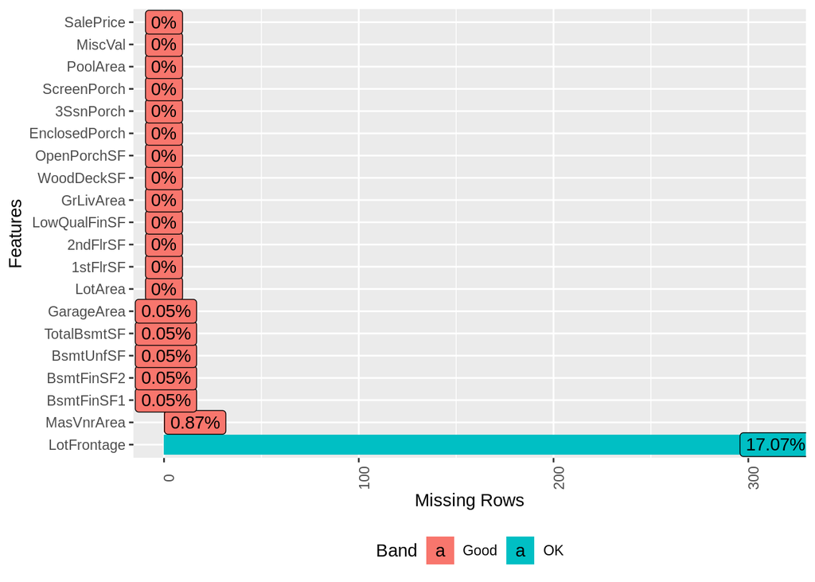

```r
missing_data_continuas <- train %>% dplyr::select(var_continuas) %>% plot_missing(theme_config = list(legend.position = "bottom", axis.text.x =element_text(angle = 90),axis.text.y = element_text(size = rel(1))))
```

- Datos faltantes en las variables: **LotFrontage**, **MasVnrArea**, **BsmtFinSF1**, **BsmtFinSF2**, **BsmtUnfSF**, **TotalBsmtSF**, **GarageArea**.

**Variables discretas:**

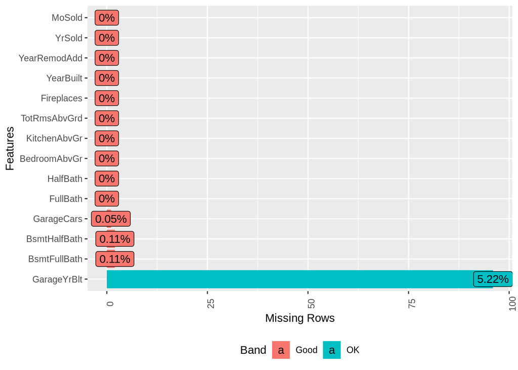

```r
missing_data_discretas <- train %>% dplyr::select(var_discretas) %>% plot_missing(theme_config = list(legend.position = "bottom", axis.text.x =element_text(angle = 90),axis.text.y = element_text(size = rel(1))))
```

- Datos faltantes en las variables: **GarageYrBlt**, **BsmtFullBath**, **BsmtHalfBath**, **GarageCars**.

**Variables discretas ordinales:**

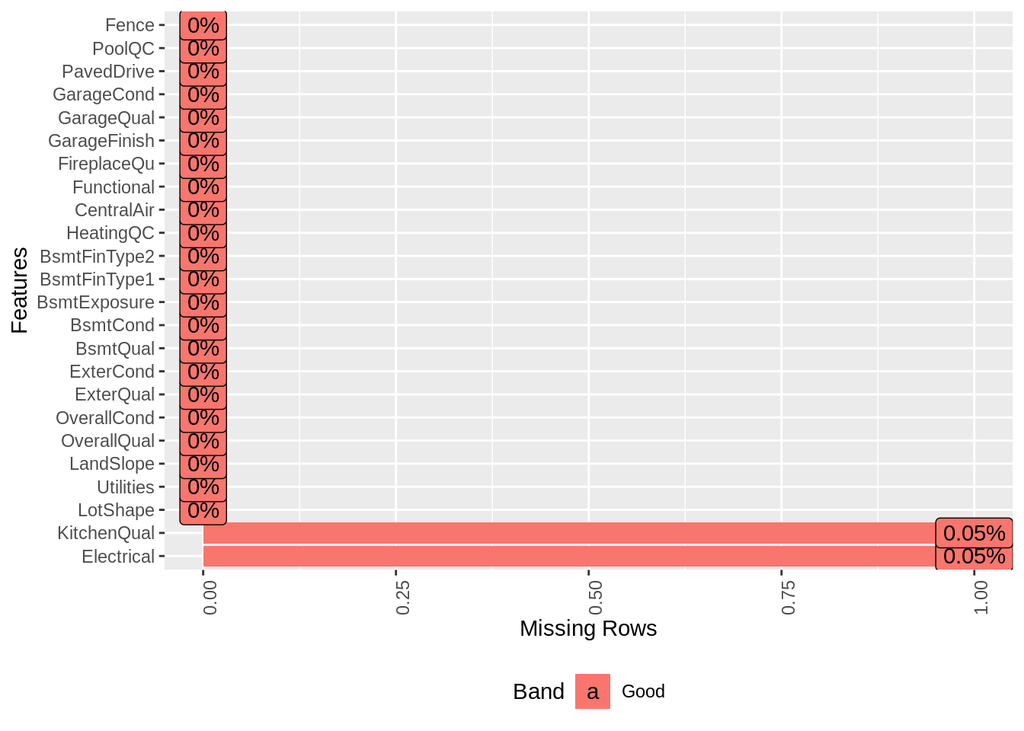

```r
missing_data_ordinales <- train %>%  dplyr::select(var_ordinales)  %>% plot_missing(theme_config = list(legend.position = "bottom", axis.text.x =element_text(angle = 90),axis.text.y = element_text(size = rel(1))))
```

- Datos faltantes en las variables: **Electrical**, **KitchenQual**.

**Variables nominales:**

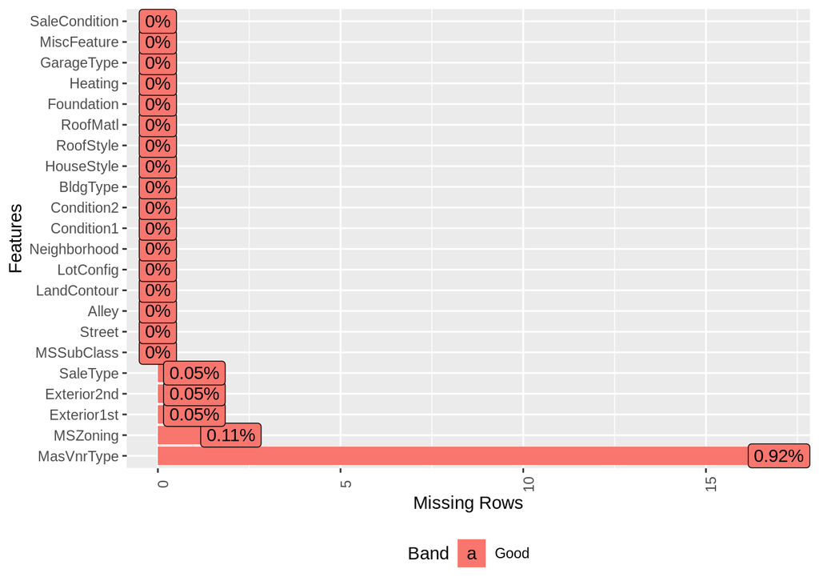

```r
missing_data_nominales <- train %>%  dplyr::select(var_nominales)  %>% plot_missing(theme_config = list(legend.position = "bottom", axis.text.x =element_text(angle = 90),axis.text.y = element_text(size = rel(1))))
```

- Datos faltantes en las variables: **SaleType**, **Exterior2nd**, **Exterior1st**, **MSZoning**, **MasVnrType**.

Como hay muchas variables que no tienen valores faltantes, vamos a crear un dataset únicamente con las columnas que tienen missings para poder analizar mejor los datos.

```r
var_missing <- c(var_missing_continuas, var_missing_discretas, var_missing_nominales, var_missing_ordinales)

train_na <- train %>% dplyr::select(var_missing)

na_counts <- sapply(train_na, function(x) sum(is.na(x)))
na_counts_sort <- sort(na_counts, decreasing = TRUE)
(na_counts_sort)
```

```
##  LotFrontage  GarageYrBlt   MasVnrType   MasVnrArea BsmtFullBath BsmtHalfBath
##          314           96           17           16            2            2
##     MSZoning   BsmtFinSF1   BsmtFinSF2    BsmtUnfSF  TotalBsmtSF   GarageArea
##            2            1            1            1            1            1
##   GarageCars     SaleType  Exterior2nd  Exterior1st   Electrical  KitchenQual
##            1            1            1            1            1            1
```

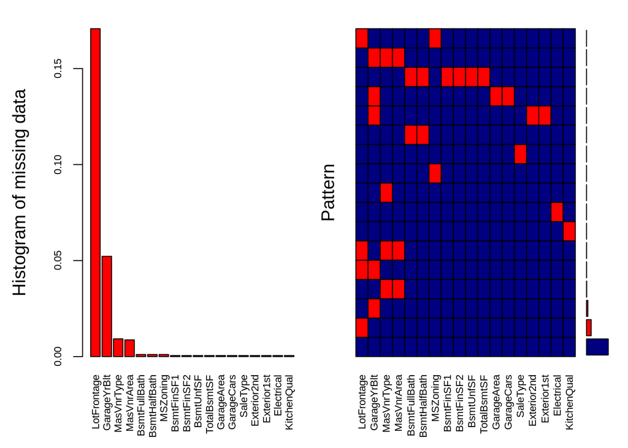

```
##
##  Variables sorted by number of missings:
##      Variable        Count
##   LotFrontage 0.1707449701
##   GarageYrBlt 0.0522022838
##    MasVnrType 0.0092441544
##    MasVnrArea 0.0087003806
##  BsmtFullBath 0.0010875476
##  BsmtHalfBath 0.0010875476
##      MSZoning 0.0010875476
##    BsmtFinSF1 0.0005437738
##    BsmtFinSF2 0.0005437738
##     BsmtUnfSF 0.0005437738
##   TotalBsmtSF 0.0005437738
##    GarageArea 0.0005437738
##    GarageCars 0.0005437738
##      SaleType 0.0005437738
##   Exterior2nd 0.0005437738
##   Exterior1st 0.0005437738
##    Electrical 0.0005437738
##   KitchenQual 0.0005437738
```

```r
aggr_plot <- aggr(train_na,col=c('navyblue','red'), numbers=TRUE, sortVars=TRUE, cex.axis=.7, gap=3, ylab=c("Histogram of missing data","Pattern"))
```

Ahora podemos prestar verdadera atención a las columnas con datos faltantes.

Si nos fijamos en la columna que más datos faltantes tiene, podemos ver en la descripción del dataset que son la cantidad de pies lineales que hay de acera hasta la puerta de la casa. Además, leyendo la documentación del dataset vemos que los NA’s no significa que no tengan conexión con la acera (un edificio de varios pisos por ejemplo), sino que son datos faltantes.

### Proporción de datos faltantes

Hemos considerado que una variable con más de un **15% de datos faltantes** nos va a desbalancear el dataset drásticamente, por lo que vamos a prescindir de este valor para nuestro estudio y para la imputación de missings, por lo que la **borramos** del dataset.

Para el caso en el que la proporción de datos faltantes sea **menor que el 3% (0.03)** imputaremos a los valores faltantes de **variables cuantitativas su mediana o media**, mientras que a las **variables categóricas** les imputaremos la **categoría más frecuente**.

Para las columnas en que la proporcion de datos faltantes sea superior al 3% (0.03) tendremos que utilizar técnicas de imputación más avanzadas. Si en nuestro dataset se diera el caso en el que existen varias columnas de este último tipo habría que realizar un análisis de sensibilidad para comprobar que no hemos alterado la naturaleza del dataset imputando los datos faltantes.

Solo nos faltaría una variable por imputar sus valores: GarageYrBlt. Esta variable indica el año en el que se construyó el garaje de la propiedad. No lo vamos a imputar con el valor medio ya que la proporción de datos faltantes es mayor al 3%, así que lo que proponemos para su imputación es lo siguiente:

Como conocemos el vecindario al que pertenecen los pisos, es lógico que el año de construcción del garaje sea similar para todo el vecindario. Vamos a proceder **a agrupar los garages por vecindario** e **imputaremos el año medio** correspondiente.

```
##  Neighborhood         mean_data
##  Length:25          Min.   :1945
##  Class :character   1st Qu.:1968
##  Mode  :character   Median :1976
##                     Mean   :1978
##                     3rd Qu.:1995
##                     Max.   :2005
```

```
##  Neighborhood         mean_data
##  Length:25          Min.   :1945
##  Class :character   1st Qu.:1968
##  Mode  :character   Median :1976
##                     Mean   :1978
##                     3rd Qu.:1995
##                     Max.   :2005
```

Y ya tendríamos todas las columnas con datos faltantes imputadas.

## Analisis y procesado de variables

Ahora comenzaremos con el análisis univariante de los datos del dataset. Empezaremos dicho análisis mostrando un conjunto de histogramas para las variables nominales:

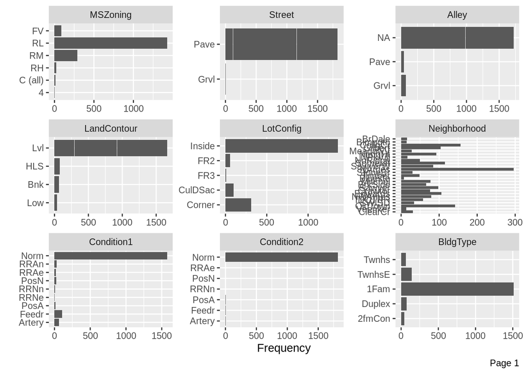

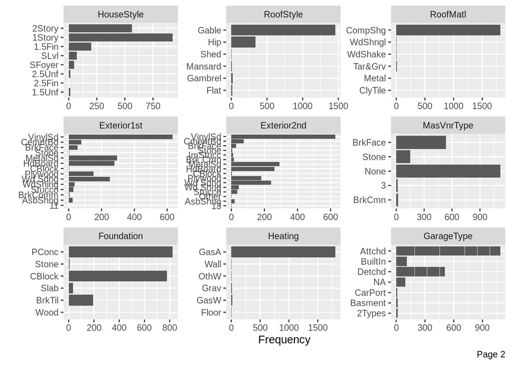

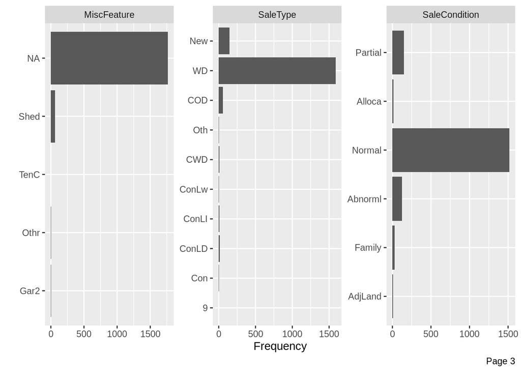

```r
train %>%  dplyr::select(var_nominales)  %>% plot_bar()
```

Estas variables pueden ser problemáticas al realizar el proceso de regresión lineal para el que este tipo de variables puede ser problemático, por no contar que para estos modelos este tipo de variables tienen muy poco poder predictivo.

El siguiente código detectara las variables que tienen baja varianza e intentara eliminar todas aquellas que no sean significativas en una regresión de ella con la variable salePrice.

```r
elementosBajaVarianza <- nearZeroVar(train,freqCut = 95/5,uniqueCut = 10)

var_eliminar_correlacion <- c()

# funcion para eliminar elementos con baja correlacion
lmp <- function (modelobject) {
    if (class(modelobject) != "lm") stop("No es un objeto de tipo regresion lineal 'lm' ")
    f <- summary(modelobject)$fstatistic
    p <- pf(f[1],f[2],f[3],lower.tail=F)
    attributes(p) <- NULL
    return(p)
}

# estas columna dan problemas, la varible 3SnnPorch empieza por un número y a la hora de ejecutar el modelo para ver si son significativas en la regresión
var_to_remove = c(var_to_remove,'3SsnPorch')

for(i in colnames(train)[elementosBajaVarianza]) {
  if(i != '3SsnPorch') {
    modelRegression <- lm(reformulate(termlabels = i, response = 'SalePrice') ,data=train)
    if(lmp(modelRegression) >.05) {
      var_eliminar_correlacion = c(var_eliminar_correlacion,i)
    }
  }
}

(var_eliminar_correlacion)
```

```
## [1] "Street"       "Utilities"    "LandSlope"    "Condition2"   "LowQualFinSF"
## [6] "Functional"   "MiscFeature"  "MiscVal"
```

```r
var_to_remove <- c(var_to_remove,var_eliminar_correlacion)
```

Ahora realizaremos el mismo análisis con las variables ordinales, que no son otra cosa que variables categóricas pero que encierran una relación de orden interna. El tratamiento de estas variables para transformarlas en categóricas y cambiar el ordenamiento alfabético que R les da por defecto:

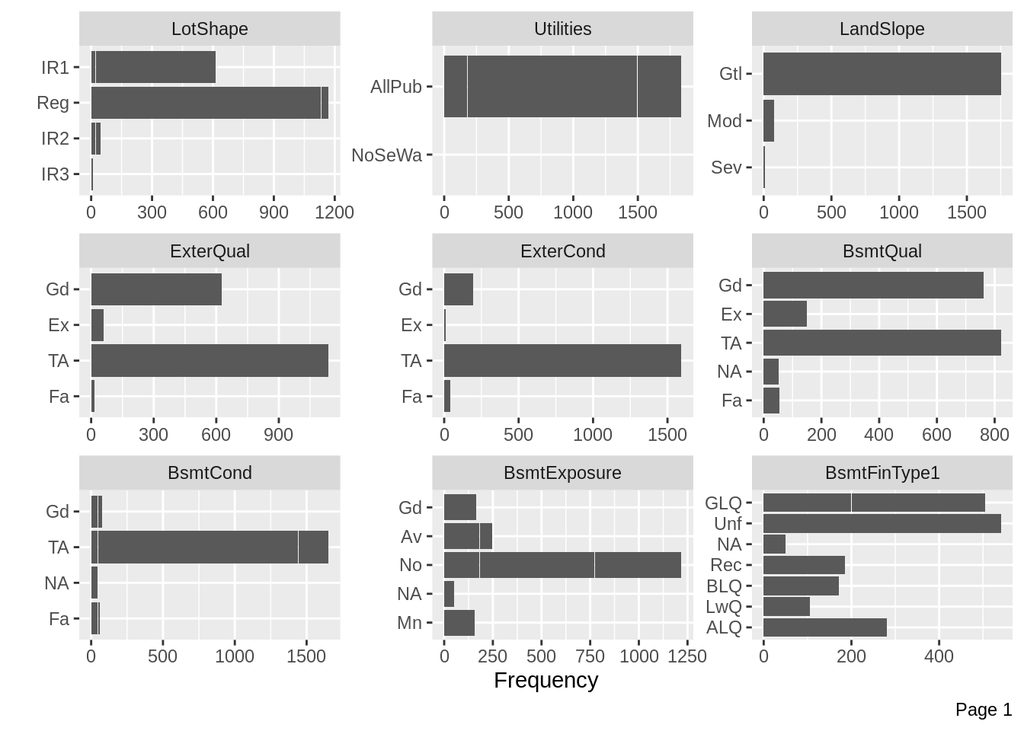

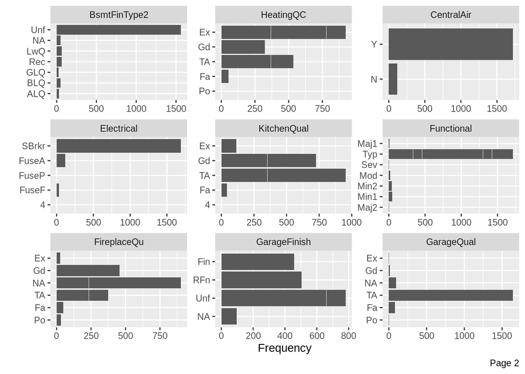

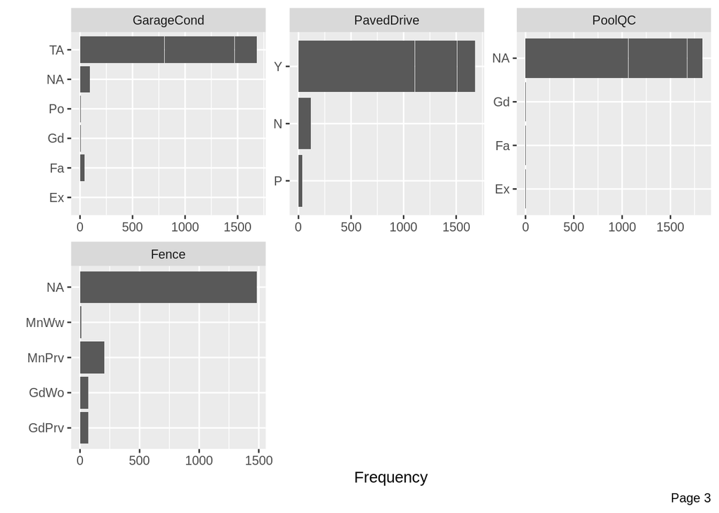

```r
train %>%  dplyr::select(var_ordinales)  %>% plot_bar()
```

Se observan práctimante las mismas anomalías en en el caso anterior, variables con distribuciones muy alejadas de la normalidad y en muchos casos dichas variables apenas aportan información debido a que la mayoría de los valores están concentrados en una única categoría.

Proseguiremos con las variables contínuas:

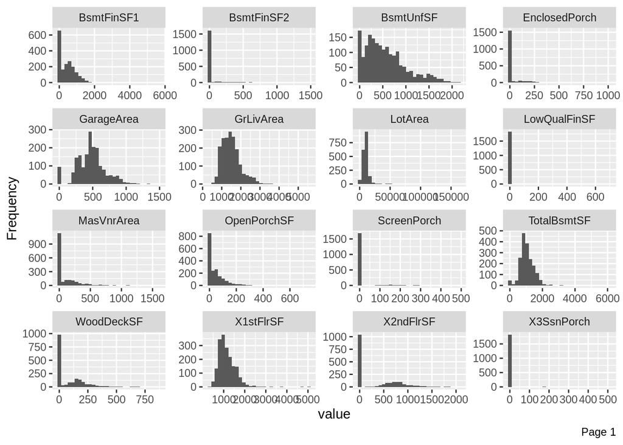

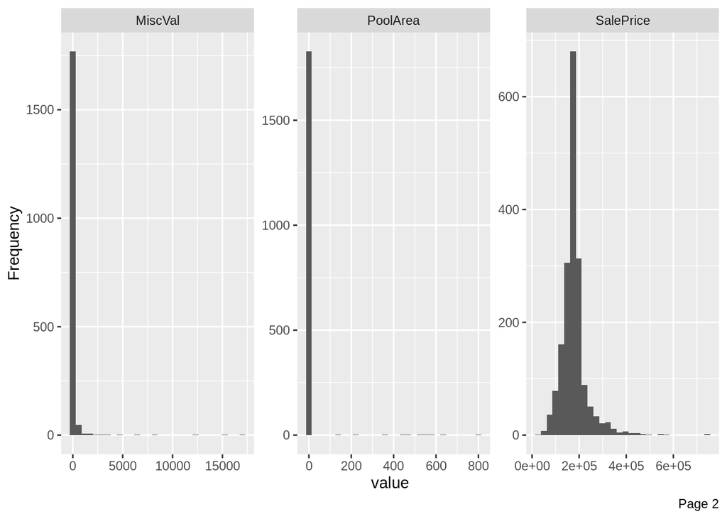

```r
var_continuas <- c('LotArea','MasVnrArea','BsmtFinSF1','BsmtFinSF2','BsmtUnfSF','TotalBsmtSF','1stFlrSF','2ndFlrSF','LowQualFinSF','GrLivArea','GarageArea','WoodDeckSF','OpenPorchSF','EnclosedPorch', '3SsnPorch','ScreenPorch','PoolArea','MiscVal','SalePrice')

train %>%  dplyr::select(var_continuas) %>% plot_histogram()
```

  Nos centraremos ahora en mostrar con mas detalle los histograma y diagramas de densidad de las variables que describen el tamaño en superficie de cada parte en la que se compone una casa: